# Rで行列・固有値分解：複素固有値編

## 固有値が複素数の場合

$$M = V S V^{-1}$$
ただし、Sは対角行列

というとき、Sの対角成分は複素数でもよい

$M$の成分が実数であるためには、共役複素数である必要はある

```r
lambda1 <- 1.1 + 1i * 0.1
lambda1
```

```
## [1] 1.1+0.1i
```

```r
lambda2 <- Conj(lambda1) # 共役複素数
lambda2
```

```
## [1] 1.1-0.1i
```

```r
S <- diag(c(lambda1,lambda2))
S
```

```
##          [,1]     [,2]
## [1,] 1.1+0.1i 0.0+0.0i
## [2,] 0.0+0.0i 1.1-0.1i
```

固有ベクトルも成分同士が共役にすると、$Mc$は実数行列になる

```r
eigen.v1 <- c(rnorm(1)+1i*rnorm(1),rnorm(1)+1i*rnorm(1))
eigen.v2 <- Conj(eigen.v1)
eigen.v1
```

```
## [1] -1.6430136-0.3225336i -0.5007177+0.4177475i
```

```r
eigen.v2
```

```
## [1] -1.6430136+0.3225336i -0.5007177-0.4177475i
```

```r
V <- cbind(eigen.v1,eigen.v2)
V.inv <- solve(V)
V
```

```
##                   eigen.v1              eigen.v2
## [1,] -1.6430136-0.3225336i -1.6430136+0.3225336i
## [2,] -0.5007177+0.4177475i -0.5007177-0.4177475i
```

```r
V.inv
```

```
##                       [,1]                  [,2]
## [1,] -0.2463531+0.2952822i -0.1902038-0.9689145i
## [2,] -0.2463531-0.2952822i -0.1902038+0.9689145i
```

```r
V %*% V.inv
```

```
##                  [,1]                       [,2]
## [1,]  1.000000e+00+0i -5.55112e-17-2.220446e-16i
## [2,] -2.775558e-17+0i  1.00000e+00-0.000000e+00i
```

```r
M <- V %*% S %*% V.inv
M
```

```
##               [,1]          [,2]
## [1,] 1.18113910+0i -0.3306574-0i
## [2,] 0.05015329+0i  1.0188609+0i
```

虚部が0なので実行列に直しておく

```r
M <- matrix(Re(M),2,2)
M
```

```
##            [,1]       [,2]
## [1,] 1.18113910 -0.3306574
## [2,] 0.05015329  1.0188609
```

固有値分解しなおす

```r
eigen.out <- eigen(M)
eigen.out
```

```
## eigen() decomposition
## $values
## [1] 1.1+0.1i 1.1-0.1i
##
## $vectors
##                    [,1]               [,2]
## [1,] 0.9318254+0.00000i 0.9318254+0.00000i
## [2,] 0.2286581-0.28181i 0.2286581+0.28181i
```

固有値は指定したものそのもの

固有ベクトルは様子が違う

```r
S
```

```
##          [,1]     [,2]
## [1,] 1.1+0.1i 0.0+0.0i
## [2,] 0.0+0.0i 1.1-0.1i
```

```r
eigen.out$values
```

```
## [1] 1.1+0.1i 1.1-0.1i
```

```r
V
```

```
##                   eigen.v1              eigen.v2
## [1,] -1.6430136-0.3225336i -1.6430136+0.3225336i
## [2,] -0.5007177+0.4177475i -0.5007177-0.4177475i
```

```r
eigen.out$vectors
```

```
##                    [,1]               [,2]
## [1,] 0.9318254+0.00000i 0.9318254+0.00000i
## [2,] 0.2286581-0.28181i 0.2286581+0.28181i
```

ただし、固有ベクトルは「定数倍」しても意味に変わりはないから、確認してみると、確かに、定数倍(ただし、複素数)になっている

```r
eigen.out$vectors / V
```

```
##                   eigen.v1              eigen.v2
## [1,] -0.5460995+0.1072027i -0.5460995-0.1072027i
## [2,] -0.5460995+0.1072027i -0.5460995-0.1072027i
```

これがどういう行列だったかと言うと

- (1,0) -> (x,y)
- (0,1) -> (z,w)

確かめる

```r
v1 <- c(1,0)
M %*% v1
```

```
##            [,1]
## [1,] 1.18113910
## [2,] 0.05015329
```

```r
v2 <- c(0,1)
M %*% v2
```

```
##            [,1]
## [1,] -0.3306574
## [2,]  1.0188609
```

この検算は一括して行える

```r
v12 <- cbind(v1,v2)
v12
```

```
##      v1 v2
## [1,]  1  0
## [2,]  0  1
```

```r
M %*% v12
```

```
##              v1         v2
## [1,] 1.18113910 -0.3306574
## [2,] 0.05015329  1.0188609
```

v12 は単位行列

単位行列は簡単に作れる

```r
I <- diag(c(1,1)) # 対角成分を引数で指定する
I
```

```
##      [,1] [,2]
## [1,]    1    0
## [2,]    0    1
```

Mが起こす変化を図にしてみる

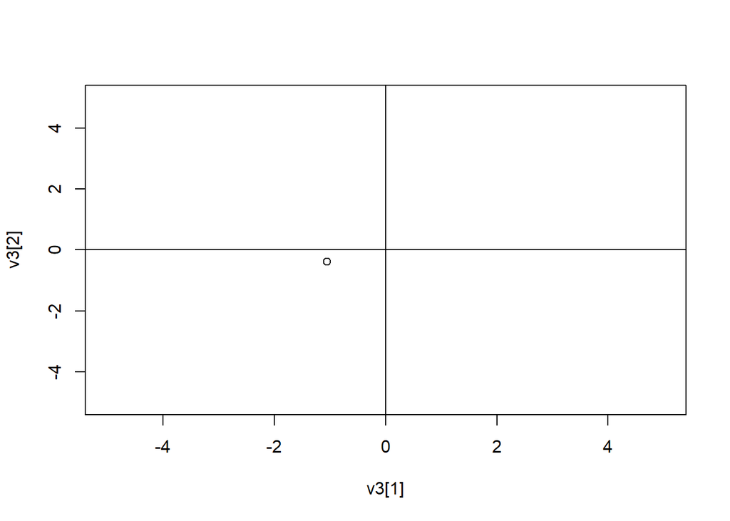

```r
v3 <- rnorm(2) # 2つの乱数(正規分布に従う正規乱数)を発生させて、適当な点をとる
plot(v3[1],v3[2],xlim=c(-5,5),ylim=c(-5,5)) # xlim,ylimはx軸,y軸の範囲を指定する
abline(h=0) # y=0 の水平(horizontal)線を引く
abline(v=0) # x=0 の鉛直(vertical)線を引く
```

v3にMを作用させる(移動させる)

```r
v3. <- M %*% v3
v3.
```

```
##            [,1]
## [1,] -1.1160535
## [2,] -0.4492805
```

合わせてプロットする

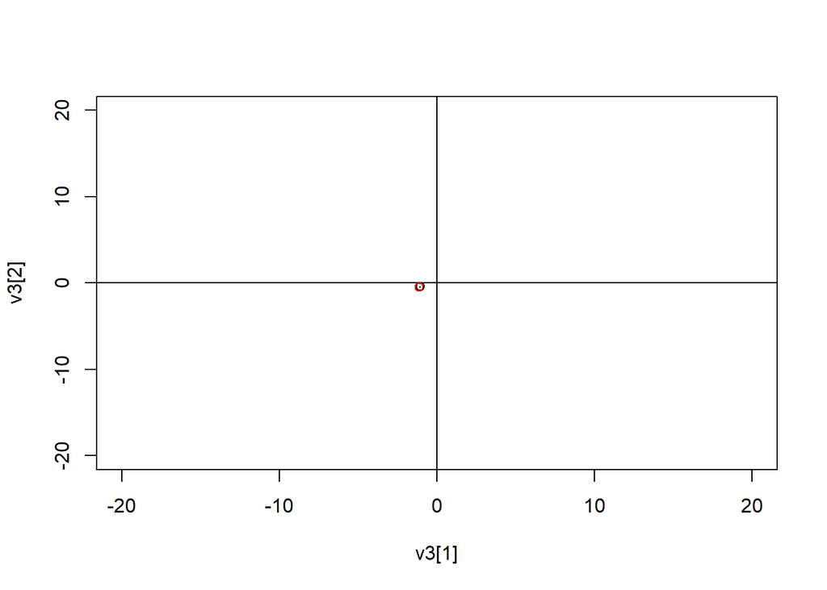

```r
plot(v3[1],v3[2],xlim=c(-20,20),ylim=c(-20,20)) # xlim,ylimはx軸,y軸の範囲を指定する
abline(h=0) # y=0 の水平(horizontal)線を引く
abline(v=0) # x=0 の鉛直(vertical)線を引く
points(v3.[1],v3.[2],col=2)
segments(v3[1],v3[2],v3.[1],v3.[2])
```

多数の点をまとめて移動させてみる

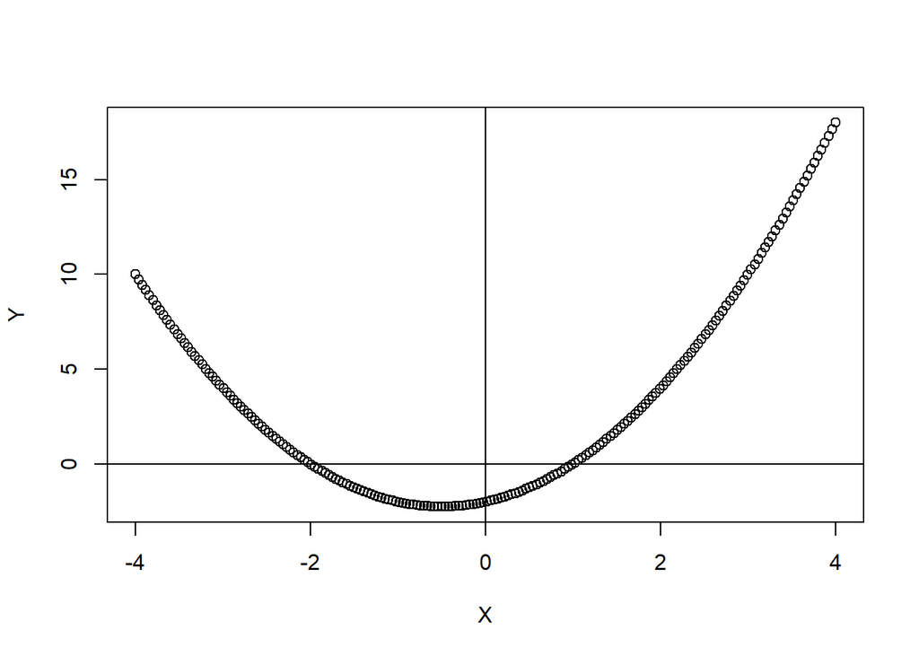

```r
p.pt <- 200
X <- seq(from=-4,to=4,length=p.pt)
Y <- (X + 2) * (X - 1)
plot(X,Y,type="b")
abline(h=0)
abline(v=0)
```

まとめてMを作用させてみる

各列が座標ならよいから、Xを１行目(１段目)、Yを２行目(２段目)にしたXYを作る

```r
XY <- rbind(X,Y)
XY[,1:5] # 初めの５点だけ見ておく
```

```
##   [,1]      [,2]      [,3]      [,4]      [,5]
## X   -4 -3.959799 -3.919598 -3.879397 -3.839196
## Y   10  9.720209  9.443650  9.170324  8.900230
```

```r
dim(XY)
```

```
## [1]   2 200
```

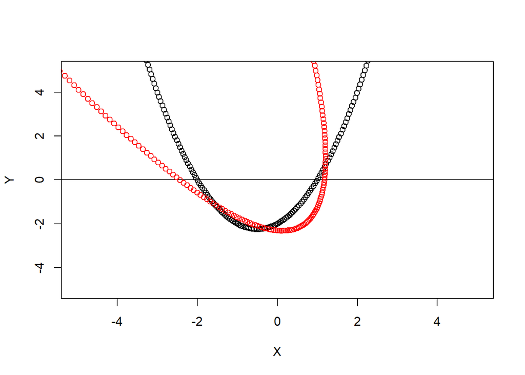

```r
XY. <- M %*% XY
plot(X,Y,type="b",xlim=c(-5,5),ylim=c(-5,5))
abline(h=0)
abline(x=0)
points(XY.[1,],XY.[2,],col=2,type="b")
```

どの点がどの点に動いたのか示しておく

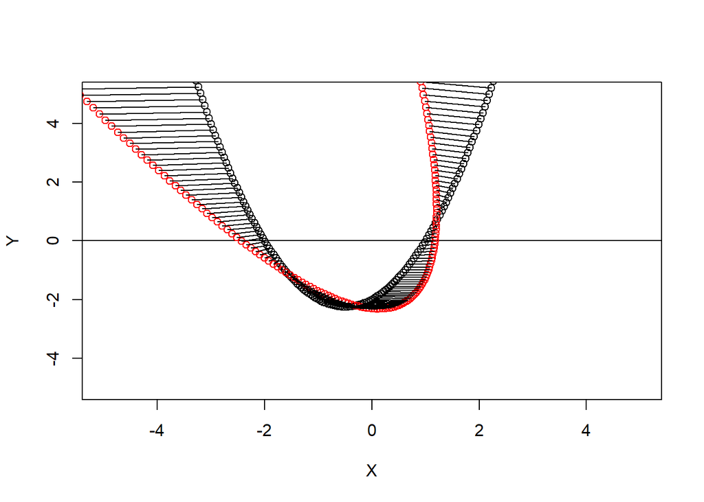

```r
XY. <- M %*% XY
plot(X,Y,type="b",xlim=c(-5,5),ylim=c(-5,5))
abline(h=0)
abline(x=0)
points(XY.[1,],XY.[2,],col=2,type="b")
segments(X,Y,XY.[1,],XY.[2,])
```

たくさん動いた点と、ほとんど動かない点とがある

## 固有値・固有ベクトルの復習

行列$M$の固有値と固有ベクトルは、以下の式を満たす$\lambda$と$x$のこと
$$Mx = \lambda x$$

Rでは以下のようにして、固有値と固有ベクトルを計算する

```r
eigen.out <- eigen(M)
eigen.out
```

```
## eigen() decomposition
## $values
## [1] 1.1+0.1i 1.1-0.1i
##
## $vectors
##                    [,1]               [,2]
## [1,] 0.9318254+0.00000i 0.9318254+0.00000i
## [2,] 0.2286581-0.28181i 0.2286581+0.28181i
```

固有値は

```r
eigen.out$values # またはeigen.out[[1]]
```

```
## [1] 1.1+0.1i 1.1-0.1i
```

固有ベクトルは

```r
eigen.out$vectors # またはeigen.out[[2]]
```

```
##                    [,1]               [,2]
## [1,] 0.9318254+0.00000i 0.9318254+0.00000i
## [2,] 0.2286581-0.28181i 0.2286581+0.28181i
```

### 検算

$$Mx = \lambda x$$

検算してみる

```r
M %*% eigen.out$vectors[,1]
```

```
##                      [,1]
## [1,] 1.0250080+0.0931825i
## [2,] 0.2797049-0.2871252i
```

```r
eigen.out$values[1] * eigen.out$vectors[,1]
```

```
## [1] 1.0250080+0.0931825i 0.2797049-0.2871252i
```

```r
M %*% eigen.out$vectors[,2]
```

```
##                      [,1]
## [1,] 1.0250080-0.0931825i
## [2,] 0.2797049+0.2871252i
```

```r
eigen.out$values[2] * eigen.out$vectors[,2]
```

```
## [1] 1.0250080-0.0931825i 0.2797049+0.2871252i
```

２つの固有値・２つの固有ベクトルを一括して検算することもできる

```r
M %*% eigen.out$vectors
```

```
##                      [,1]                 [,2]
## [1,] 1.0250080+0.0931825i 1.0250080-0.0931825i
## [2,] 0.2797049-0.2871252i 0.2797049+0.2871252i
```

```r
eigen.out$values[1] * eigen.out$vectors[,1]
```

```
## [1] 1.0250080+0.0931825i 0.2797049-0.2871252i
```

```r
eigen.out$values[2] * eigen.out$vectors[,2]
```

```
## [1] 1.0250080-0.0931825i 0.2797049+0.2871252i
```

```r
S <- diag(eigen.out$values)
S # 固有値の対角行列
```

```
##          [,1]     [,2]
## [1,] 1.1+0.1i 0.0+0.0i
## [2,] 0.0+0.0i 1.1-0.1i
```

```r
S %*% eigen.out$vectors
```

```
##                      [,1]                 [,2]
## [1,] 1.0250080+0.0931825i 1.0250080+0.0931825i
## [2,] 0.2233429-0.3328568i 0.2797049+0.2871252i
```

```r
M %*% eigen.out$vectors
```

```
##                      [,1]                 [,2]
## [1,] 1.0250080+0.0931825i 1.0250080-0.0931825i
## [2,] 0.2797049-0.2871252i 0.2797049+0.2871252i
```

## 固有値・固有ベクトルを図示する

固有値が意味するのは、(x,y)成分別に何倍するか

その固有値が複素数であるので、(x,y)成分別に、複素数の長さを定数倍して、複素数の位相を回転させること

その様子をみてみる

直線が回転しながら長さを変えている様子が見て取れる

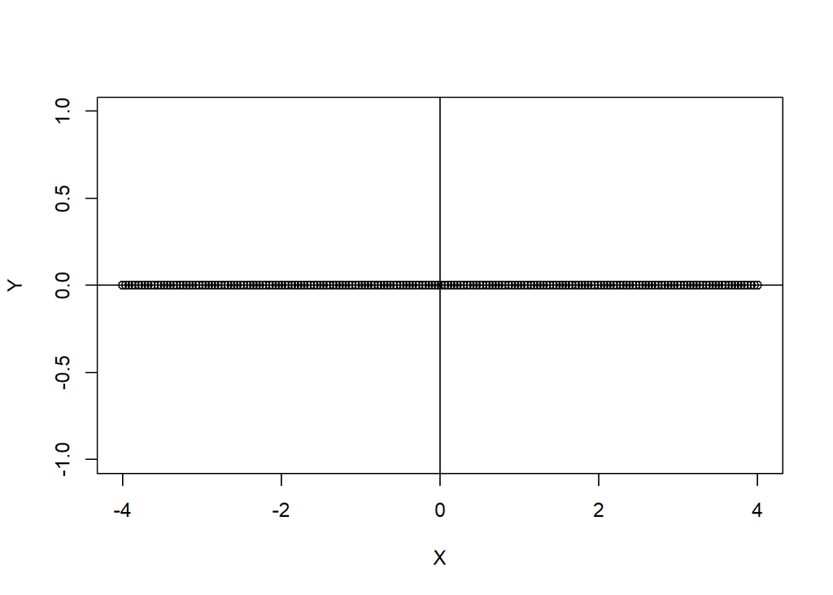

```r
p.pt <- 200
X <- seq(from=-4,to=4,length=p.pt)
Y <- rep(0,p.pt)
plot(X,Y,type="b")
abline(h=0)
abline(v=0)
```

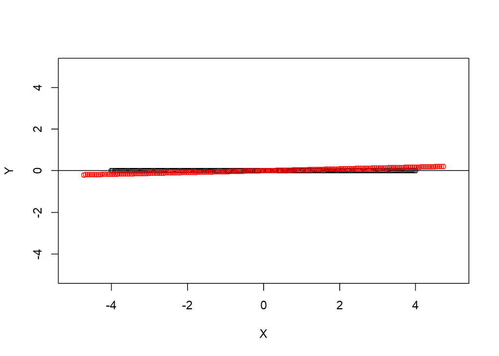

```r
XY <- rbind(X,Y)
XY. <- M %*% XY
plot(X,Y,type="b",xlim=c(-5,5),ylim=c(-5,5))
abline(h=0)
abline(x=0)
points(XY.[1,],XY.[2,],col=2,type="b")
```

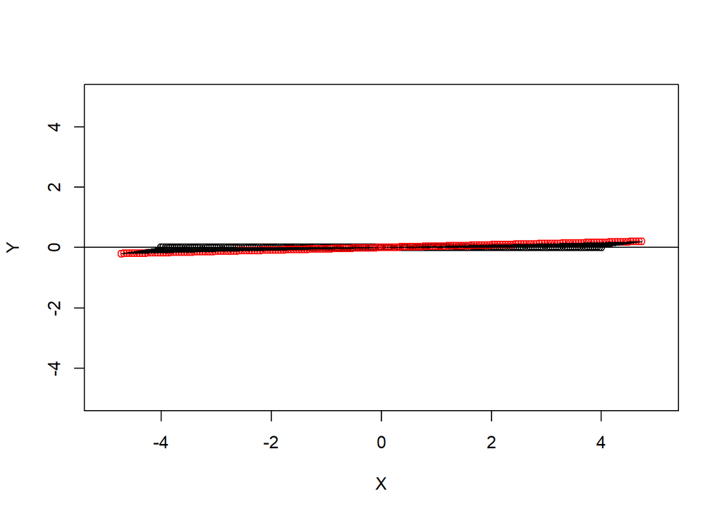

```r
XY. <- M %*% XY
plot(X,Y,type="b",xlim=c(-5,5),ylim=c(-5,5))
abline(h=0)
abline(x=0)
points(XY.[1,],XY.[2,],col=2,type="b")
segments(X,Y,XY.[1,],XY.[2,])
```

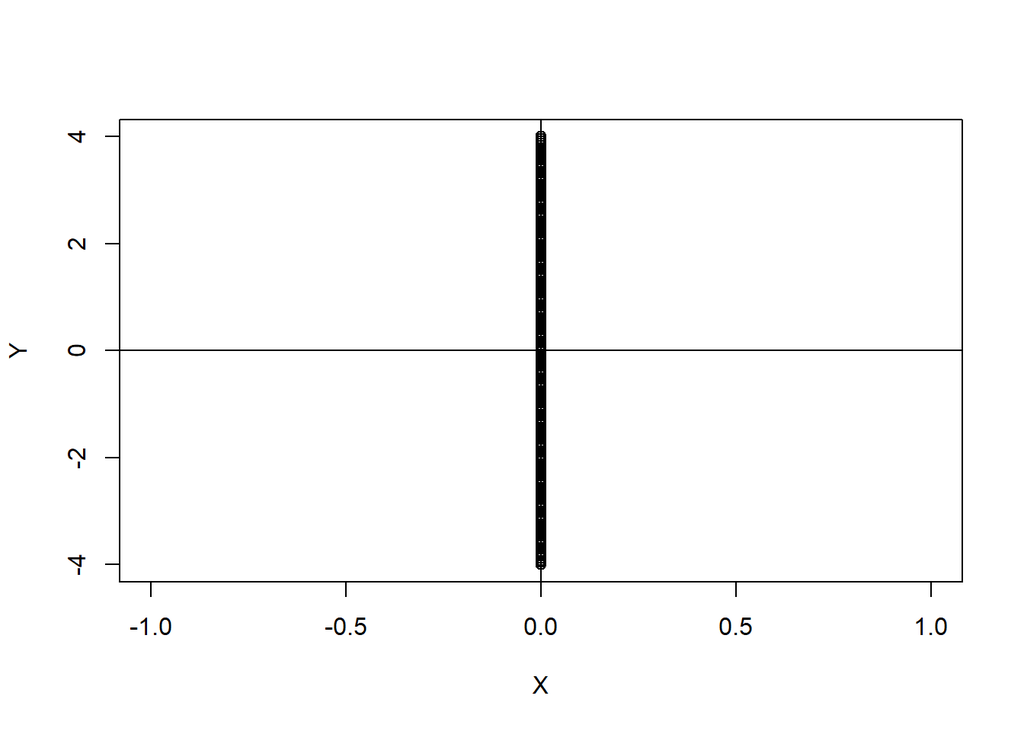

```r
p.pt <- 200
Y <- seq(from=-4,to=4,length=p.pt)
X <- rep(0,p.pt)
plot(X,Y,type="b")
abline(h=0)
abline(v=0)
```

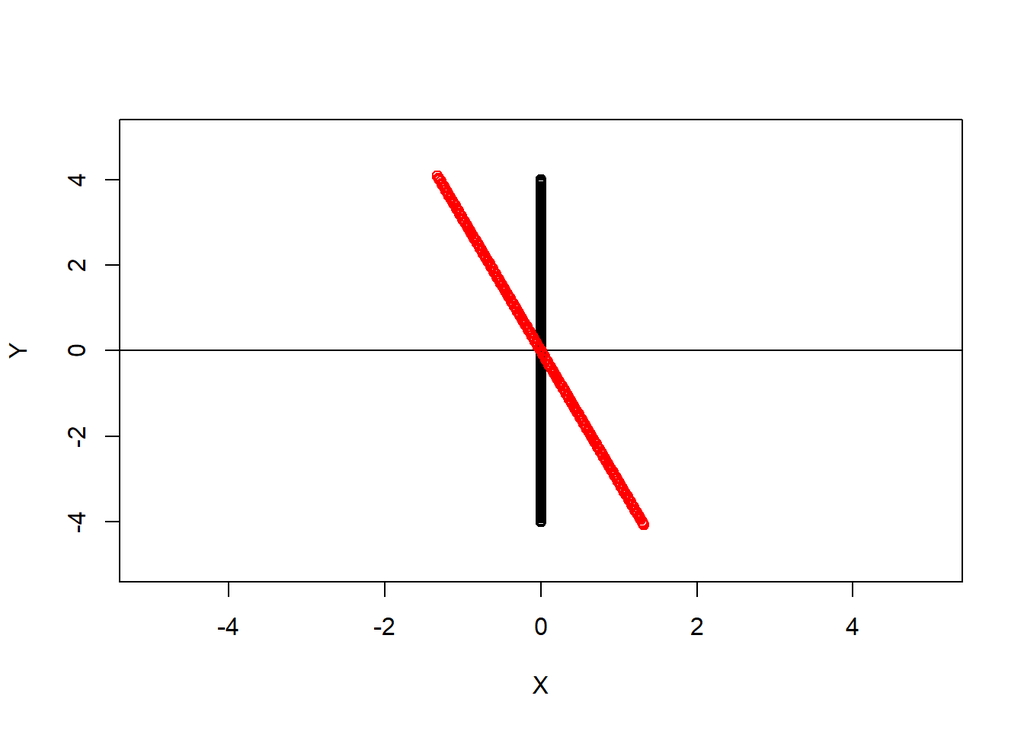

```r
XY <- rbind(X,Y)
XY. <- M %*% XY
plot(X,Y,type="b",xlim=c(-5,5),ylim=c(-5,5))
abline(h=0)
abline(x=0)
points(XY.[1,],XY.[2,],col=2,type="b")
```

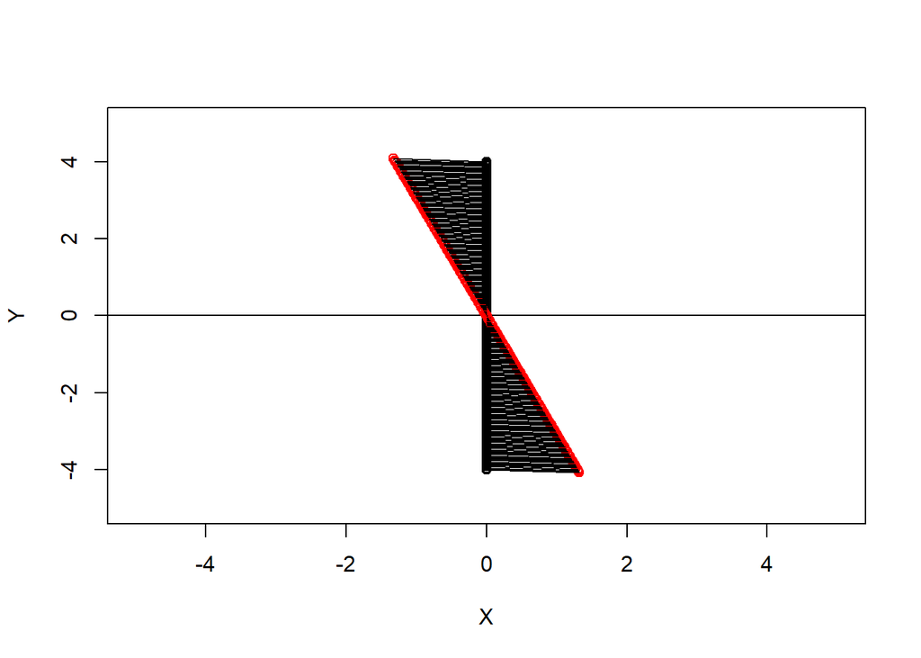

```r
XY. <- M %*% XY
plot(X,Y,type="b",xlim=c(-5,5),ylim=c(-5,5))
abline(h=0)
abline(x=0)
points(XY.[1,],XY.[2,],col=2,type="b")
segments(X,Y,XY.[1,],XY.[2,])
```

点の移動の様子を、関数上の点に限らず図示する

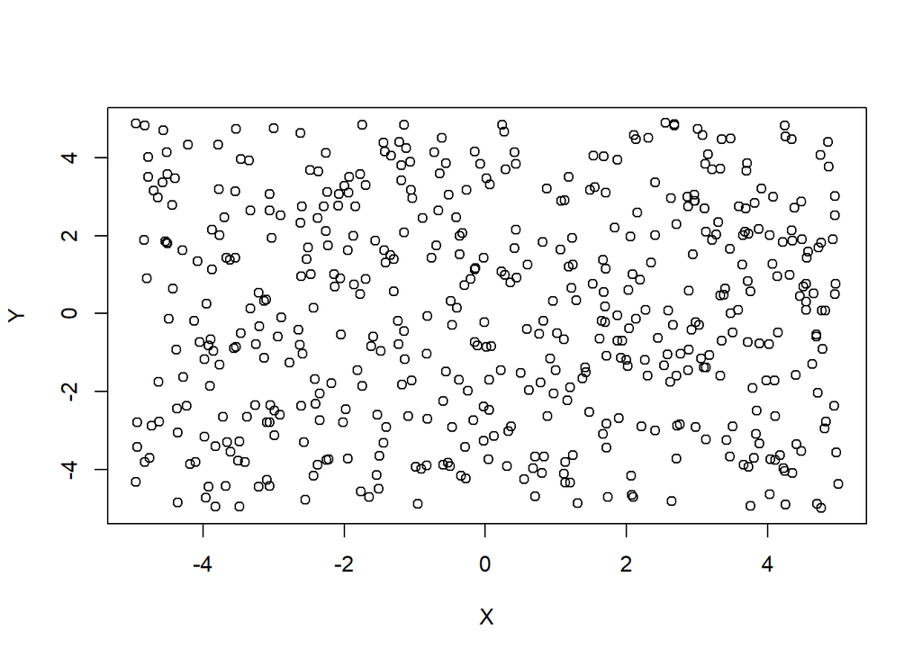

```r
n.pt <- 500
X <- runif(n.pt,min=-5,max=5)
Y <- runif(n.pt,min=-5,max=5)
plot(X,Y)
```

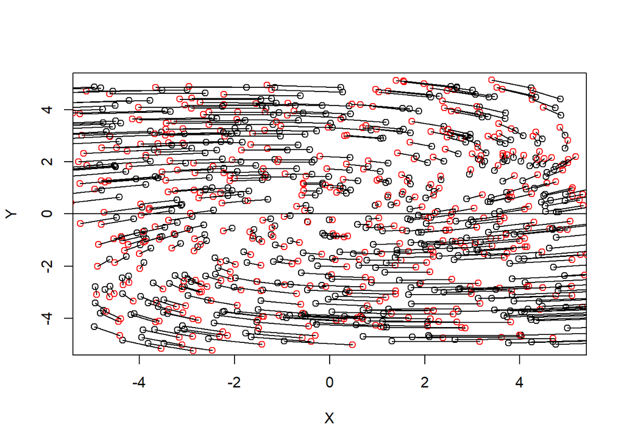

```r
XY <- rbind(X,Y)
XY. <- M %*% XY
plot(X,Y,xlim=c(-5,5),ylim=c(-5,5))
points(XY.[1,],XY.[2,],col=2)
segments(X,Y,XY.[1,],XY.[2,])
abline(h=0)
abline(x=0)
```

### 固有値分解の「分解」という意味

```r
V <- eigen.out$vectors
S <- diag(eigen.out$values)
S
```

```
##          [,1]     [,2]
## [1,] 1.1+0.1i 0.0+0.0i
## [2,] 0.0+0.0i 1.1-0.1i
```

```r
V.inv <- solve(V)
V %*% V.inv
```

```
##                            [,1] [,2]
## [1,] 1.000000e+00+0.000000e+00i 0+0i
## [2,] 4.163336e-17+5.551115e-17i 1+0i
```

```r
V.inv %*% V
```

```
##                     [,1]                [,2]
## [1,] 1e+00+0.000000e+00i 0e+00+5.551115e-17i
## [2,] 0e+00-5.551115e-17i 1e+00-0.000000e+00i
```

分解されている

```r
V %*% S %*% V.inv
```

```
##               [,1]          [,2]
## [1,] 1.18113910+0i -0.3306574+0i
## [2,] 0.05015329+0i  1.0188609+0i
```

```r
M
```

```
##            [,1]       [,2]
## [1,] 1.18113910 -0.3306574
## [2,] 0.05015329  1.0188609
```

固有値はMの重要な情報

重要な情報は対角成分に集約される

```r
sum(S) # 固有値分解で取り出した対角行列
```

```
## [1] 2.2+0i
```

```r
sum(eigen.out$values) # sum(S)と同じこと
```

```
## [1] 2.2+0i
```

```r
M
```

```
##            [,1]       [,2]
## [1,] 1.18113910 -0.3306574
## [2,] 0.05015329  1.0188609
```

```r
diag(M)
```

```
## [1] 1.181139 1.018861
```

```r
sum(diag(M)) # Mのトレース
```

```
## [1] 2.2
```

行列式も大事な情報

それは固有値の積

```r
det(M)
```

```
## [1] 1.22
```

```r
prod(eigen.out$values)
```

```
## [1] 1.22+0i
```

これはたまたま起きることではない

```r
d <- 100 # d x d 行列
M2 <- matrix(rnorm(d^2),d,d)
eigen.out2 <- eigen(M2)
sum(eigen.out2$values)
```

```
## [1] -0.8415382+0i
```

```r
sum(diag(M2))
```

```
## [1] -0.8415382
```

```r
prod(eigen.out2$values)
```

```
## [1] -1.760481e+76+0e+00i
```

```r
det(M2)
```

```
## [1] -1.760481e+76
```